# DM Project

Elyse Zhang

7/16/2018

```r
library(readr)
```

```r
diabetic.data = read_csv("/Users/Elyse/Documents/UChicago/Courses/Summer 2018/Data Mining/Projects/Project/dataset_diabetes/diabetic_data.csv")
str(diabetic.data)
```

```
## Classes 'tbl_df', 'tbl' and 'data.frame':    101766 obs. of  50 variables:
##  $ encounter_id            : int  2278392 149190 64410 500364 16680 35754 55842 63768 12522 15738 ...
##  $ patient_nbr             : int  8222157 55629189 86047875 82442376 42519267 82637451 84259809 114882984 48330783 63555939 ...
##  $ race                    : chr  "Caucasian" "Caucasian" "AfricanAmerican" "Caucasian" ...
##  $ gender                  : chr  "Female" "Female" "Female" "Male" ...
##  $ age                     : chr  "[0-10)" "[10-20)" "[20-30)" "[30-40)" ...
##  $ weight                  : chr  "?" "?" "?" "?" ...
##  $ admission_type_id       : int  6 1 1 1 1 2 3 1 2 3 ...
##  $ discharge_disposition_id: int  25 1 1 1 1 1 1 1 1 3 ...
##  $ admission_source_id     : int  1 7 7 7 7 2 2 7 4 4 ...
##  $ time_in_hospital        : int  1 3 2 2 1 3 4 5 13 12 ...
##  $ payer_code              : chr  "?" "?" "?" "?" ...
##  $ medical_specialty       : chr  "Pediatrics-Endocrinology" "?" "?" "?" ...
##  $ num_lab_procedures      : int  41 59 11 44 51 31 70 73 68 33 ...
##  $ num_procedures          : int  0 0 5 1 0 6 1 0 2 3 ...
##  $ num_medications         : int  1 18 13 16 8 16 21 12 28 18 ...
##  $ number_outpatient       : int  0 0 2 0 0 0 0 0 0 0 ...
##  $ number_emergency        : int  0 0 0 0 0 0 0 0 0 0 ...
##  $ number_inpatient        : int  0 0 1 0 0 0 0 0 0 0 ...
##  $ diag_1                  : chr  "250.83" "276" "648" "8" ...
##  $ diag_2                  : chr  "?" "250.01" "250" "250.43" ...
##  $ diag_3                  : chr  "?" "255" "V27" "403" ...
##  $ number_diagnoses        : int  1 9 6 7 5 9 7 8 8 8 ...
##  $ max_glu_serum           : chr  "None" "None" "None" "None" ...
##  $ A1Cresult               : chr  "None" "None" "None" "None" ...
##  $ metformin               : chr  "No" "No" "No" "No" ...
##  $ repaglinide             : chr  "No" "No" "No" "No" ...
##  $ nateglinide             : chr  "No" "No" "No" "No" ...
##  $ chlorpropamide          : chr  "No" "No" "No" "No" ...
##  $ glimepiride             : chr  "No" "No" "No" "No" ...
##  $ acetohexamide           : chr  "No" "No" "No" "No" ...
##  $ glipizide               : chr  "No" "No" "Steady" "No" ...
##  $ glyburide               : chr  "No" "No" "No" "No" ...
##  $ tolbutamide             : chr  "No" "No" "No" "No" ...
##  $ pioglitazone            : chr  "No" "No" "No" "No" ...
##  $ rosiglitazone           : chr  "No" "No" "No" "No" ...
##  $ acarbose                : chr  "No" "No" "No" "No" ...
##  $ miglitol                : chr  "No" "No" "No" "No" ...
##  $ troglitazone            : chr  "No" "No" "No" "No" ...
##  $ tolazamide              : chr  "No" "No" "No" "No" ...
```

[output cut: 101 more lines]

[output not shown]

## 1. Data Processing

### 1.1. Missing values andd Feature Engineering

```r
library(dplyr)
library(stats)
```

**race**

```r
diabetic.data %>%
  group_by(race) %>%
  summarise(count = n()) %>%
  mutate(ratio = count/sum(count)) %>%
  arrange(desc(ratio))
```

```
## # A tibble: 6 x 3
##   race            count   ratio
##   <chr>           <int>   <dbl>
## 1 Caucasian       76099 0.748
## 2 AfricanAmerican 19210 0.189
## 3 ?                2273 0.0223
## 4 Hispanic         2037 0.0200
## 5 Other            1506 0.0148
## 6 Asian             641 0.00630
```

```r
#For this one, missing data can be shared among Caucasian and African American say roughly 80-20.
set.seed(2273)
race.filling = sample(c("Caucasian","AfricanAmerican"), 2273, replace=TRUE, prob = c(0.8,0.2))
```

```r
diabetic.data$race[which(diabetic.data$race == '?')] = race.filling
diabetic.data$race = as.numeric(as.factor(diabetic.data$race))
```

**Mapping: African American 1, Asian 2, Caucasian 3, Hispanic 4, Other 5**

**gender**

```r
diabetic.data %>%
  group_by(gender) %>%
  summarise(count = n()) %>%
  mutate(ratio = count/sum(count))
```

```
## # A tibble: 3 x 3
##   gender          count     ratio
##   <chr>           <int>     <dbl>
## 1 Female          54708 0.538
## 2 Male            47055 0.462
## 3 Unknown/Invalid     3 0.0000295
```

```r
set.seed(3)
gender.filling = sample(c("Female","Male"), 3, replace=TRUE, prob = c(0.5,0.5))

diabetic.data$gender[which(diabetic.data$gender == 'Unknown/Invalid')] = gender.filling
```

```r
diabetic.data$gender = as.numeric(as.factor(diabetic.data$gender))
```

**Mapping: F 1, M 2**

**age**

```r
diabetic.data %>%
  group_by(age) %>%
  summarise(count = n()) %>%
  mutate(ratio = count/sum(count))
```

```
## # A tibble: 10 x 3
##    age      count   ratio
##    <chr>    <int>   <dbl>
##  1 [0-10)     161 0.00158
##  2 [10-20)    691 0.00679
##  3 [20-30)   1657 0.0163
##  4 [30-40)   3775 0.0371
##  5 [40-50)   9685 0.0952
##  6 [50-60)  17256 0.170
##  7 [60-70)  22483 0.221
##  8 [70-80)  26068 0.256
##  9 [80-90)  17197 0.169
## 10 [90-100)  2793 0.0274
```

We can have less groups, children+ young adult(0-20), adult(20-40), middle age(40-60),senior(60-80), very senior(80-100). Before we do that, we can fill in people age with 70 with Medicare as their insurance in case they are missing.

**payer_code**

```r
diabetic.data %>%
  group_by(payer_code) %>%
  summarise(count = n()) %>%
  mutate(ratio = count/sum(count)) %>%
  arrange(desc(ratio))
```

```
## # A tibble: 18 x 3
##    payer_code count      ratio
##    <chr>      <int>      <dbl>
##  1 ?          40256 0.396
##  2 MC         32439 0.319
##  3 HM          6274 0.0617
##  4 SP          5007 0.0492
##  5 BC          4655 0.0457
##  6 MD          3532 0.0347
##  7 CP          2533 0.0249
##  8 UN          2448 0.0241
##  9 CM          1937 0.0190
## 10 OG          1033 0.0102
## 11 PO           592 0.00582
## 12 DM           549 0.00539
## 13 CH           146 0.00143
## 14 WC           135 0.00133
## 15 OT            95 0.000934
## 16 MP            79 0.000776
## 17 SI            55 0.000540
## 18 FR             1 0.00000983
```

We started with 40% of the data unknown, 31.9% on Medicare, and 4.92% selfpay , rest ~25% insured.. So we can do regroup based on the known groups.We can reduce unknown data by assuming ppl over 65, in this case 70 are all on Medicare.

```r
diabetic.data[((diabetic.data$age %in% c("[70-80)","[80-90)","[90-100)")) & (diabetic.data$payer_code =='?')),]$payer_code = 2 #2 is medicare
```

```r
table(diabetic.data$payer_code)
```

```
##
##     ?     2    BC    CH    CM    CP    DM    FR    HM    MC    MD    MP
## 23245 17011  4655   146  1937  2533   549     1  6274 32439  3532    79
##    OG    OT    PO    SI    SP    UN    WC
##  1033    95   592    55  5007  2448   135
```

**reduced missing value of insurance by half**

```r
diabetic.data[diabetic.data$payer_code =="MC",]$payer_code = 2 #2 is medicare
diabetic.data[diabetic.data$payer_code =="SP",]$payer_code = 3 #3 is selfpay
diabetic.data[diabetic.data$payer_code =="?",]$payer_code = 4 #4 is unknown
diabetic.data[!diabetic.data$payer_code %in% c(2,3,4),]$payer_code = 1 #1 is insured other

diabetic.data$payer_code = as.factor(diabetic.data$payer_code)
```

```r
diabetic.data[diabetic.data$age %in% c("[0-10)","[10-20)"),]$age = 1
diabetic.data[diabetic.data$age %in% c("[20-30)","[30-40)"),]$age = 2
diabetic.data[diabetic.data$age %in% c("[40-50)","[50-60)"),]$age = 3
diabetic.data[diabetic.data$age %in% c("[60-70)","[70-80)"),]$age = 4
diabetic.data[diabetic.data$age %in% c("[80-90)","[90-100)"),]$age = 5
```

**weight**

```r
diabetic.data %>%
  group_by(weight) %>%
  summarise(count = n()) %>%
  mutate(ratio = count/sum(count))
```

```
## # A tibble: 10 x 3
##    weight    count     ratio
##    <chr>     <int>     <dbl>
##  1 ?         98569 0.969
##  2 [0-25)       48 0.000472
##  3 [100-125)   625 0.00614
##  4 [125-150)   145 0.00142
##  5 [150-175)    35 0.000344
##  6 [175-200)    11 0.000108
##  7 [25-50)      97 0.000953
##  8 [50-75)     897 0.00881
##  9 [75-100)   1336 0.0131
## 10 >200          3 0.0000295
```

**We decided not to use Weight**

```r
diabetic.data %>%
  group_by(admission_type_id) %>%
  summarise(count = n()) %>%
  mutate(ratio = count/sum(count))
```

```
## # A tibble: 8 x 3
##   admission_type_id count     ratio
##               <int> <int>     <dbl>
## 1                 1 53990 0.531
## 2                 2 18480 0.182
## 3                 3 18869 0.185
## 4                 4    10 0.0000983
## 5                 5  4785 0.0470
## 6                 6  5291 0.0520
## 7                 7    21 0.000206
## 8                 8   320 0.00314
```

**Map admission_type_id description 1 Emergency 2 Urgent 3 Elective 4 Newborn 5 Not Available 6 NULL 7 Trauma Center 8 Not Mapped**

We can essentially combine 5,6,8 as a group, and make 4 Newborn as part of 2 Urgent and 7 Trauma Center as part of 1 emergency

```r
diabetic.data[diabetic.data$admission_type_id == 7,]$admission_type_id = 1
diabetic.data[diabetic.data$admission_type_id == 4,]$admission_type_id = 2
diabetic.data[diabetic.data$admission_type_id %in% c(5,6,8),]$admission_type_id = 4
```

**New mapping 1 Emergency 2 Urgent 3 Elective 4 Not Available**

**discharge_disposition_id**

```r
diabetic.data %>%
  group_by(discharge_disposition_id) %>%
  summarise(count = n()) %>%
  mutate(ratio = count/sum(count))
```

```
## # A tibble: 26 x 3
##    discharge_disposition_id count     ratio
##                       <int> <int>     <dbl>
##  1                        1 60234 0.592
##  2                        2  2128 0.0209
##  3                        3 13954 0.137
##  4                        4   815 0.00801
##  5                        5  1184 0.0116
##  6                        6 12902 0.127
##  7                        7   623 0.00612
##  8                        8   108 0.00106
##  9                        9    21 0.000206
## 10                       10     6 0.0000590
## # ... with 16 more rows
```

```r
diabetic.data[diabetic.data$discharge_disposition_id %in% c(2:5,9,10,12,15:17,22:24,27:30),]$discharge_disposition_id = 2

diabetic.data[diabetic.data$discharge_disposition_id %in% c(6,8),]$discharge_disposition_id = 3

diabetic.data[diabetic.data$discharge_disposition_id %in% c(7,18,25),]$discharge_disposition_id = 4

diabetic.data[diabetic.data$discharge_disposition_id %in% c(11,13:14,19:21),]$discharge_disposition_id = 5

# WILL NEED TO DELETE GROUP 5 WHILING DOING PREDICTION**
```

**admission_source_id**

```r
diabetic.data %>%
  group_by(admission_source_id) %>%
  summarise(count = n()) %>%
  mutate(ratio = count/sum(count))
```

```
## # A tibble: 17 x 3
##    admission_source_id count      ratio
##                  <int> <int>      <dbl>
##  1                   1 29565 0.291
##  2                   2  1104 0.0108
##  3                   3   187 0.00184
##  4                   4  3187 0.0313
##  5                   5   855 0.00840
##  6                   6  2264 0.0222
##  7                   7 57494 0.565
##  8                   8    16 0.000157
##  9                   9   125 0.00123
## 10                  10     8 0.0000786
## 11                  11     2 0.0000197
## 12                  13     1 0.00000983
## 13                  14     2 0.0000197
## 14                  17  6781 0.0666
## 15                  20   161 0.00158
## 16                  22    12 0.000118
## 17                  25     2 0.0000197
```

Old mapping 1:6,8, 10,18,19,22,25,26 are referals or transfers from different facilities or home with less urgency, where as 7,11-14 and 23 24 are urgent from emergency room or premature birth etc. 9,15,17 20,21 are NAs.

```r
diabetic.data[diabetic.data$admission_source_id %in% c(1:6,8,10,18,19,22,25,26),]$admission_source_id = 1

diabetic.data[diabetic.data$admission_source_id %in% c(7,11:14,23,24),]$admission_source_id = 2

diabetic.data[diabetic.data$admission_source_id %in% c(9,15,17,20,21 ),]$admission_source_id = 3
```

**New mapping, referals 1, urgent or emergency,2 nas are 3**

**medical_specialty**

```r
diabetic.data %>%
  group_by(medical_specialty) %>%
  summarise(count = n()) %>%
  arrange(desc(count)) %>%
  mutate(ratio = count/sum(count))
```

```
## # A tibble: 73 x 3
##    medical_specialty          count  ratio
##    <chr>                      <int>  <dbl>
##  1 ?                          49949 0.491
##  2 InternalMedicine           14635 0.144
##  3 Emergency/Trauma            7565 0.0743
##  4 Family/GeneralPractice      7440 0.0731
##  5 Cardiology                  5352 0.0526
##  6 Surgery-General             3099 0.0305
##  7 Nephrology                  1613 0.0159
##  8 Orthopedics                 1400 0.0138
##  9 Orthopedics-Reconstructive  1233 0.0121
## 10 Radiologist                 1140 0.0112
## # ... with 63 more rows
```

**50% of the data unknown, 15% InternalMedicine. Decide to drop assuming diagosis 1 2 3 have some overlapping information**

**diag_1**

```r
# Circulatory 390–459, 785
diabetic.data[diabetic.data$diag_1 %in% c(390:459,785),]$diag_1 = 1

# Respiratory 460–519, 786
diabetic.data[diabetic.data$diag_1 %in% c(460:519,786),]$diag_1 = 2

# Digestive 520–579, 787
diabetic.data[diabetic.data$diag_1 %in% c(520:579,787),]$diag_1 = 3

# Diabetes 250.xx
diabetic.data[substring(diabetic.data$diag_1,1,3) == 250,]$diag_1 = 4

# Injury 800–999
diabetic.data[diabetic.data$diag_1 %in% c(800:999),]$diag_1 = 5

# Musculoskeletal 710–739
diabetic.data[diabetic.data$diag_1 %in% c(710:739),]$diag_1 = 6

# Genitourinary 580–629, 788
diabetic.data[diabetic.data$diag_1 %in% c(580:629, 788),]$diag_1 = 7

# Neoplasms 140–239
diabetic.data[diabetic.data$diag_1 %in% c(140:239),]$diag_1 = 8

# Others
diabetic.data[! diabetic.data$diag_1 %in% c(1:8),]$diag_1 = 9
```

**Mapping: Circulatory 1, Respiratory 2, Digestive 3, Diabetes 4, Injury 5, Musculoskeletal 6, Genitourinary 7, Neoplasms 8, any groups covers less than 3.5% of the patients are put into others which is 9**

```r
diabetic.data %>%
  group_by(diag_1) %>%
  summarise(count = n()) %>%
  arrange(desc(count)) %>%
  mutate(ratio = count/sum(count))
```

```
## # A tibble: 9 x 3
##   diag_1 count  ratio
##   <chr>  <int>  <dbl>
## 1 1      30437 0.299
## 2 9      17654 0.173
## 3 2      14423 0.142
## 4 3       9488 0.0932
## 5 4       8757 0.0861
## 6 5       6983 0.0686
## 7 7       5119 0.0503
## 8 6       4957 0.0487
## 9 8       3948 0.0388
```

**Same mapping and methods for diagosis 2 and 3**

```r
# Circulatory 390–459, 785
diabetic.data[diabetic.data$diag_2 %in% c(390:459,785),]$diag_2 = 1

# Respiratory 460–519, 786
diabetic.data[diabetic.data$diag_2 %in% c(460:519,786),]$diag_2 = 2

# Digestive 520–579, 787
diabetic.data[diabetic.data$diag_2 %in% c(520:579,787),]$diag_2 = 3

# Diabetes 250.xx
diabetic.data[substring(diabetic.data$diag_2,1,3) == 250,]$diag_2 = 4

# Injury 800–999
diabetic.data[diabetic.data$diag_2 %in% c(800:999),]$diag_2 = 5

# Musculoskeletal 710–739
diabetic.data[diabetic.data$diag_2 %in% c(710:739),]$diag_2 = 6

# Genitourinary 580–629, 788
diabetic.data[diabetic.data$diag_2 %in% c(580:629, 788),]$diag_2 = 7

# Neoplasms 140–239
diabetic.data[diabetic.data$diag_2 %in% c(140:239),]$diag_2 = 8

# Others
diabetic.data[! diabetic.data$diag_2 %in% c(1:8),]$diag_2 = 9
```

```r
diabetic.data %>%
  group_by(diag_2) %>%
  summarise(count = n()) %>%
  arrange(desc(count)) %>%
  mutate(ratio = count/sum(count))
```

```
## # A tibble: 9 x 3
##   diag_2 count  ratio
##   <chr>  <int>  <dbl>
## 1 1      31881 0.313
## 2 9      26710 0.262
## 3 4      12794 0.126
## 4 2      10895 0.107
## 5 7       8377 0.0823
## 6 3       4170 0.0410
## 7 8       2746 0.0270
## 8 5       2429 0.0239
## 9 6       1764 0.0173
```

```r
# Circulatory 390–459, 785
diabetic.data[diabetic.data$diag_3 %in% c(390:459,785),]$diag_3 = 1

# Respiratory 460–519, 786
diabetic.data[diabetic.data$diag_3 %in% c(460:519,786),]$diag_3 = 2

# Digestive 520–579, 787
diabetic.data[diabetic.data$diag_3 %in% c(520:579,787),]$diag_3 = 3

# Diabetes 250.xx
diabetic.data[substring(diabetic.data$diag_3,1,3) == 250,]$diag_3 = 4

# Injury 800–999
diabetic.data[diabetic.data$diag_3 %in% c(800:999),]$diag_3 = 5

# Musculoskeletal 710–739
diabetic.data[diabetic.data$diag_3 %in% c(710:739),]$diag_3 = 6

# Genitourinary 580–629, 788
diabetic.data[diabetic.data$diag_3 %in% c(580:629, 788),]$diag_3 = 7

# Neoplasms 140–239
diabetic.data[diabetic.data$diag_3 %in% c(140:239),]$diag_3 = 8

# Others
diabetic.data[! diabetic.data$diag_3 %in% c(1:8),]$diag_3 = 9
```

```r
diabetic.data %>%
  group_by(diag_3) %>%
  summarise(count = n()) %>%
  arrange(desc(count)) %>%
  mutate(ratio = count/sum(count))
```

```
## # A tibble: 9 x 3
##   diag_3 count  ratio
##   <chr>  <int>  <dbl>
## 1 9      30421 0.299
## 2 1      30306 0.298
## 3 4      17157 0.169
## 4 2       7358 0.0723
## 5 7       6682 0.0657
## 6 3       3932 0.0386
## 7 8       2046 0.0201
## 8 5       1949 0.0192
## 9 6       1915 0.0188
```

**max_glu_serum**

```r
diabetic.data %>%
  group_by(max_glu_serum) %>%
  summarise(count = n()) %>%
  mutate(ratio = count/sum(count))
```

```
## # A tibble: 4 x 3
##   max_glu_serum count  ratio
##   <chr>         <int>  <dbl>
## 1 >200           1485 0.0146
## 2 >300           1264 0.0124
## 3 None          96420 0.947
## 4 Norm           2597 0.0255
```

```r
diabetic.data[diabetic.data$max_glu_serum == 'None',]$max_glu_serum = 1
diabetic.data[diabetic.data$max_glu_serum == 'Norm',]$max_glu_serum = 2
diabetic.data[diabetic.data$max_glu_serum %in% c('>200','>300'),]$max_glu_serum = 3
```

**New mapping None, or not measured group 1, normal group 2, and larger than 200 abnormal/elevated, group 3**

** A1Cresult **

```r
diabetic.data %>%
  group_by(A1Cresult) %>%
  summarise(count = n()) %>%
  mutate(ratio = count/sum(count))
```

```
## # A tibble: 4 x 3
##   A1Cresult count  ratio
##   <chr>     <int>  <dbl>
## 1 >7         3812 0.0375
## 2 >8         8216 0.0807
## 3 None      84748 0.833
## 4 Norm       4990 0.0490
```

```r
diabetic.data[diabetic.data$A1Cresult == 'None',]$A1Cresult = 1
diabetic.data[diabetic.data$A1Cresult == 'Norm',]$A1Cresult = 2
diabetic.data[diabetic.data$A1Cresult %in% c('>7','>8'),]$A1Cresult = 3
```

**Looking at all medications**

```r
for (i in c(25:47)) {
  print(colnames(diabetic.data)[i])
  print(table(as.factor(diabetic.data[[i]])))
  print(round(prop.table(table(as.factor(diabetic.data[[i]]))),3))
  cat('\n')
  cat('\n')
}
```

```
## [1] "metformin"
##
##   Down     No Steady     Up
##    575  81778  18346   1067
##
##   Down     No Steady     Up
##  0.006  0.804  0.180  0.010
##
##
## [1] "repaglinide"
##
##   Down     No Steady     Up
##     45 100227   1384    110
##
##   Down     No Steady     Up
##  0.000  0.985  0.014  0.001
##
##
## [1] "nateglinide"
##
##   Down     No Steady     Up
##     11 101063    668     24
##
##   Down     No Steady     Up
##  0.000  0.993  0.007  0.000
##
##
## [1] "chlorpropamide"
##
##   Down     No Steady     Up
##      1 101680     79      6
##
##   Down     No Steady     Up
##  0.000  0.999  0.001  0.000
##
##
## [1] "glimepiride"
##
##   Down     No Steady     Up
##    194  96575   4670    327
```

[output cut: 150 more lines]

```
##
##     No Steady
## 101764      2
##
##     No Steady
##      1      0
##
##
## [1] "metformin-pioglitazone"
##
##     No Steady
## 101765      1
##
##     No Steady
##      1      0
```

**There is a lot of the medicine that lack variation, can be removed**

### 1.2 Add New Features

** Number of Medication Changes ** We read that Medication change for diabetics upon admission has been shown by previous research to be associated with lower readmission rates. We decided to count how many changes were made in total for each patient, and declared that a new feature

```r
diabetic.data = diabetic.data %>%
  mutate(num_med_dose_change = apply(diabetic.data[,25:47], 1, function(x) length(which(x=='Up'|x=='Down'))))
```

```r
table(diabetic.data$num_med_dose_change)
```

```
##
##     0     1     2     3     4
## 74063 26272  1318   108     5
```

**change** Indicates if there was a change in diabetic medications (either dosage or generic name). Values: “change” as 1 and “no change” as 0.

```r
table(diabetic.data$change)
```

```
##
##    Ch    No
## 47011 54755
```

```r
diabetic.data[diabetic.data$change == 'Ch',]$change = 1
diabetic.data[diabetic.data$change == 'No',]$change= 0
```

**diabetesMed** Indicates if there was any diabetic medication prescribed. Values: “yes” and “no”

```r
table(diabetic.data$diabetesMed)
```

```
##
##    No   Yes
## 23403 78363
```

```r
diabetic.data[diabetic.data$diabetesMed == 'Yes',]$diabetesMed = 1
diabetic.data[diabetic.data$diabetesMed == 'No',]$diabetesMed= 0
```

** Recoding the outcome variable: The outcome we are looking at is whether the patient gets readmitted to the hospital within 30 days or not. The variable actually has < 30, > 30 and No Readmission categories. **

```r
table(diabetic.data$readmitted)
```

```
##
##   <30   >30    NO
## 11357 35545 54864
```

```r
diabetic.data[!diabetic.data$readmitted == '<30',]$readmitted = 0
diabetic.data[diabetic.data$readmitted == '<30',]$readmitted = 1
diabetic.data$readmitted = as.factor(diabetic.data$readmitted)
```

```r
#str(diabetic.data)
```

### 1.3. Finishing up: drop columns, change names

```r
## Drop columns
##Drop cols with missing values, Unused medications : acetohexamide, tolbutamide, miglitol, troglitazone, tolazamide, examide,citoglipton, glipizide-metformin, glimepiride-pioglitazone,metformin-rosiglitazone, metformin-pioglitazone

dropCols = c('weight','medical_specialty','acetohexamide', 'tolbutamide', 'miglitol', 'troglitazone', 'tolazamide', 'examide','citoglipton', 'glipizide-metformin', 'glimepiride-pioglitazone','metformin-rosiglitazone', 'metformin-pioglitazone' )

diabetic.data <-diabetic.data[ ,!(names(diabetic.data) %in% dropCols)]
# str(diabetic.data)
```

```r
for (i in c(3:8, 10, 17:19,21,22,35,36))
  diabetic.data[[i]] = as.factor(diabetic.data[[i]])

str(diabetic.data)
```

```
## Classes 'tbl_df', 'tbl' and 'data.frame':    101766 obs. of  38 variables:
##  $ encounter_id            : int  2278392 149190 64410 500364 16680 35754 55842 63768 12522 15738 ...
##  $ patient_nbr             : int  8222157 55629189 86047875 82442376 42519267 82637451 84259809 114882984 48330783 63555939 ...
##  $ race                    : Factor w/ 5 levels "1","2","3","4",..: 3 3 1 3 3 3 3 3 3 3 ...
##  $ gender                  : Factor w/ 2 levels "1","2": 1 1 1 2 2 2 2 2 1 1 ...
##  $ age                     : Factor w/ 5 levels "1","2","3","4",..: 1 1 2 2 3 3 4 4 5 5 ...
##  $ admission_type_id       : Factor w/ 4 levels "1","2","3","4": 4 1 1 1 1 2 3 1 2 3 ...
##  $ discharge_disposition_id: Factor w/ 5 levels "1","2","3","4",..: 4 1 1 1 1 1 1 1 1 2 ...
##  $ admission_source_id     : Factor w/ 3 levels "1","2","3": 1 2 2 2 2 1 1 2 1 1 ...
##  $ time_in_hospital        : int  1 3 2 2 1 3 4 5 13 12 ...
##  $ payer_code              : Factor w/ 4 levels "1","2","3","4": 4 4 4 4 4 4 4 2 2 2 ...
##  $ num_lab_procedures      : int  41 59 11 44 51 31 70 73 68 33 ...
##  $ num_procedures          : int  0 0 5 1 0 6 1 0 2 3 ...
##  $ num_medications         : int  1 18 13 16 8 16 21 12 28 18 ...
##  $ number_outpatient       : int  0 0 2 0 0 0 0 0 0 0 ...
```

[output cut: 24 more lines]

```r
#Reorganize and rename columns
#colnames(diabetic.data)
diabetic.data = diabetic.data[ , c(37,1:8, 10, 9,11:16,20,17:19,21:22,36,35,38,23:34)]
```

```r
#colnames(diabetic.data)
colnames(diabetic.data)[c(1,7:9,24:25)] = c("readmitted_30","admission_type","discharge_disposition","admission_source","have_diabetesMed","have_dose_brand_change")
```

Remove rows is not performed here because they are still good for clustering, but not for prediction. The rows needs to be deleted are: * ** Primary (diag_1), Secondary (diag_2) and Additional (diag_3) diagnoses were have very few missing values. Technically, if all three are missing, that’s bad data. So we only drop those records where all three diagnoses are missing, this is not done here * People deseased or transfered to hospice care**

```r
#write.csv(diabetic.data, "diabetic.data.csv", row.names=FALSE)
```

## 2. Clustering Analysis

done by Madhavi

## 3. Modeling and Prediction

```r
library(ggplot2)
library(plotROC)
library(gridExtra)
library(grid)
library(ggthemes)
```

```r
readm = diabetic.data
```

### 3.1 Additional transformation

** insulin **

```r
readm$insulin = as.factor(readm$insulin)
levels(readm$insulin)
```

```
## [1] "Down"   "No"     "Steady" "Up"
```

```r
levels(readm$insulin) = c(3,1,2,4)
str(readm$insulin)
```

```
##  Factor w/ 4 levels "3","1","2","4": 2 4 2 4 3 3 3 2 3 3 ...
```

**mapping : 1 is not having insulin, 2 is steady dose, 3 is reduced dose, 4 is inceeased dose**

**Deleting deseased patients or patients transferred to hospice care**

```r
readm = readm[!readm$discharge_disposition == 5,]
```

```r
#Deleting all the other diabetes medicines and patient id and encounter id
readm = readm[,-c(2,3,27:36,38)]
```

### 3.2. further treatment for the numerical variable

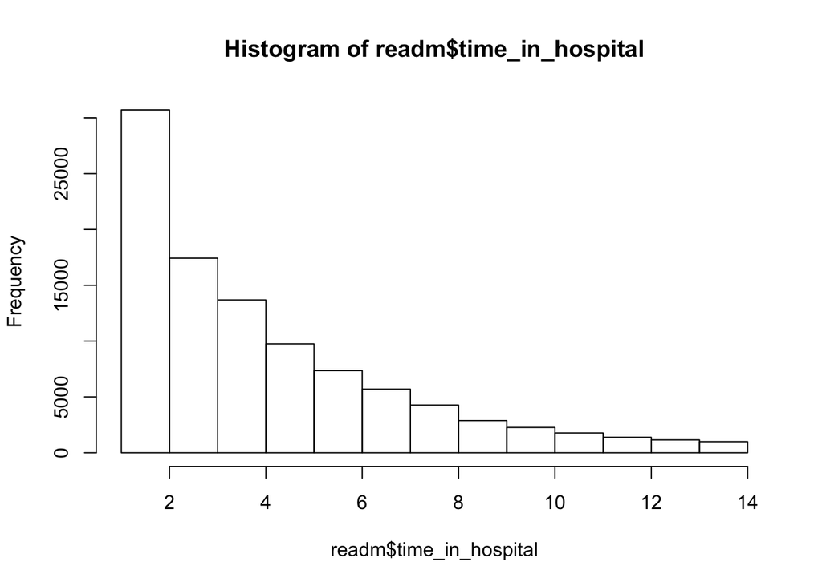

```r
hist(readm$time_in_hospital) #col9 change to factor
```

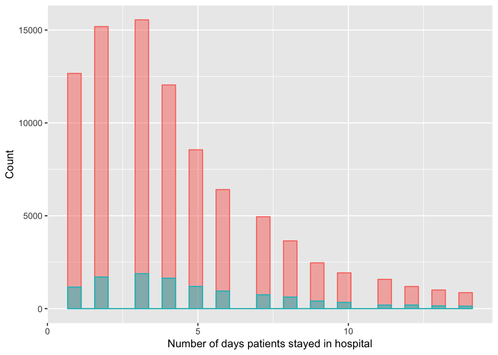

```r
ggplot(readm, aes(x=time_in_hospital, fill=readmitted_30, color=readmitted_30 )) +
  geom_histogram(position="identity", alpha=0.5) +
  theme(legend.position="none") +
  labs(x= 'Number of days patients stayed in hospital', y = 'Count')
```

```r
readm[readm$time_in_hospital<=2,]$time_in_hospital = 1
readm[(readm$time_in_hospital>2) & (readm$time_in_hospital<=5),]$time_in_hospital = 2
readm[readm$time_in_hospital>5,]$time_in_hospital = 3
```

```r
readm$time_in_hospital = as.factor(readm$time_in_hospital)
table(readm$time_in_hospital)
```

```
##
##     1     2     3
## 30715 40865 27763
```

**map: 1 <=2, 2 3-5 day, 3: longer than 5**

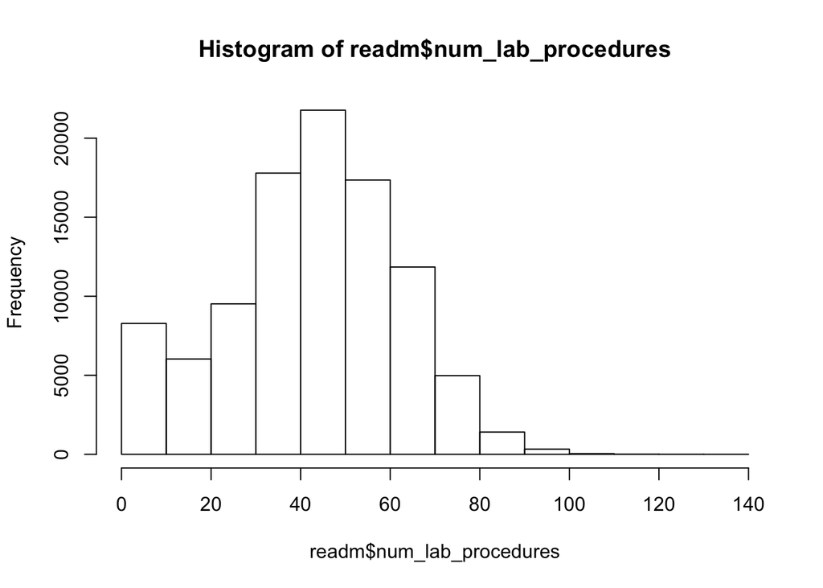

```r
hist(readm$num_lab_procedures) # col 10 no change
```

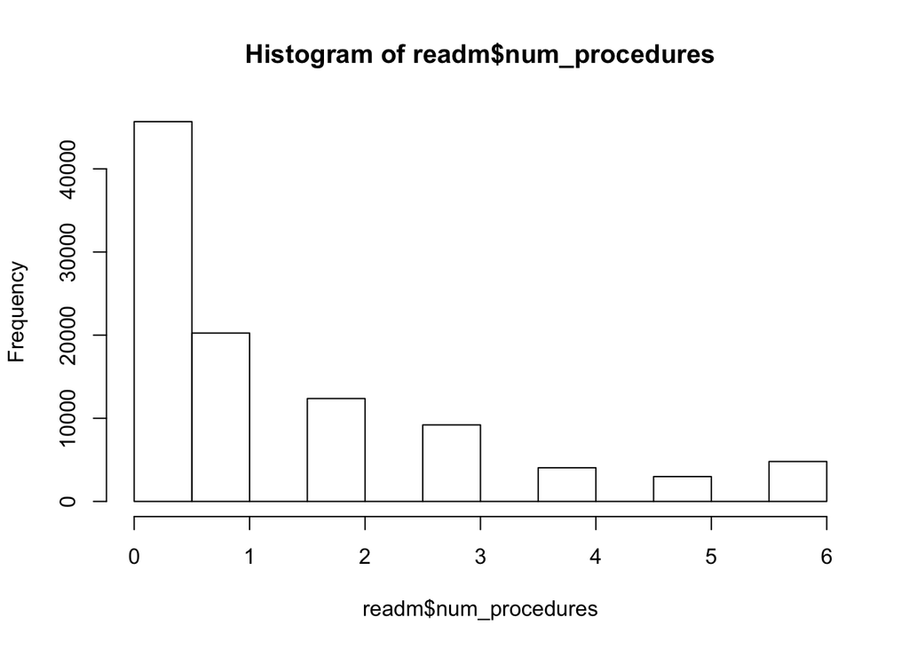

```r
hist(readm$num_procedures) #col 11 change to factor
```

```r
readm[readm$num_procedures >=4,]$num_procedures = 4
readm$num_procedures = as.factor(readm$num_procedures)
table(readm$num_procedures)
```

```
##
##     0     1     2     3     4
## 45679 20250 12373  9203 11838
```

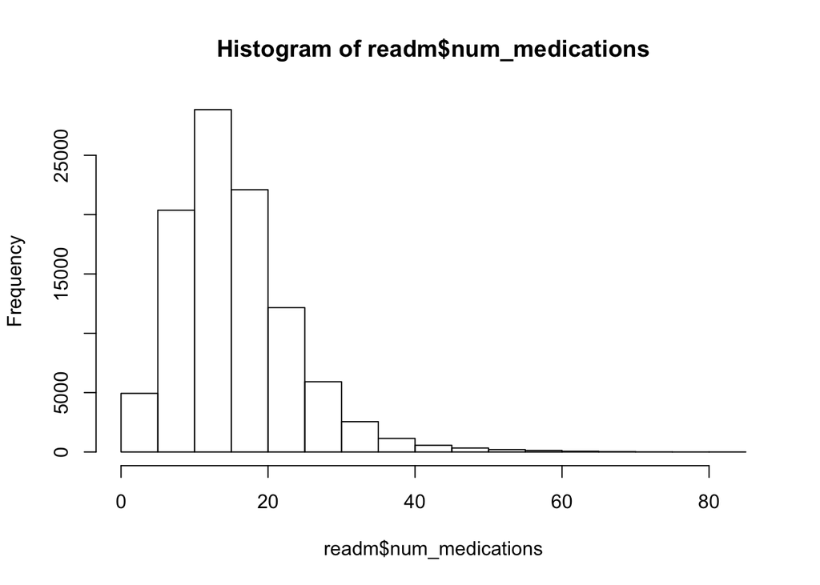

```r
hist(readm$num_medications) #col 12 log
```

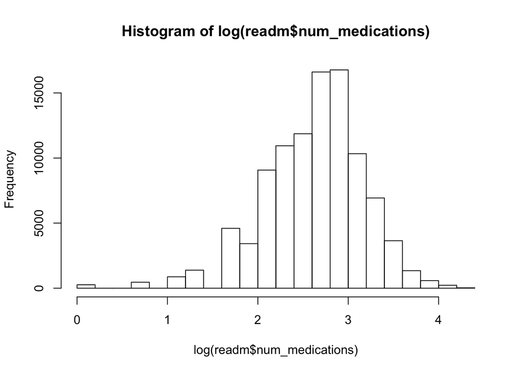

```r
hist(log(readm$num_medications))
```

```r
readm$num_medications = log(readm$num_medications)
```

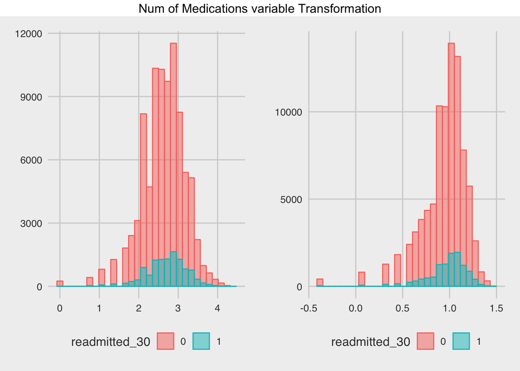

```r
p1 = ggplot(readm, aes(x=num_medications, fill=readmitted_30, color=readmitted_30)) +
  geom_histogram(position="identity", alpha=0.5) +
  theme(legend.position="none") +
  theme_fivethirtyeight()

p2 = ggplot(readm, aes(x=log(num_medications), fill=readmitted_30, color=readmitted_30)) +
  geom_histogram(position="identity", alpha=0.5) +
  theme(legend.position="none") +
  theme_fivethirtyeight()

grid.arrange(p1, p2, ncol =2, top = textGrob("Num of Medications variable Transformation"))
```

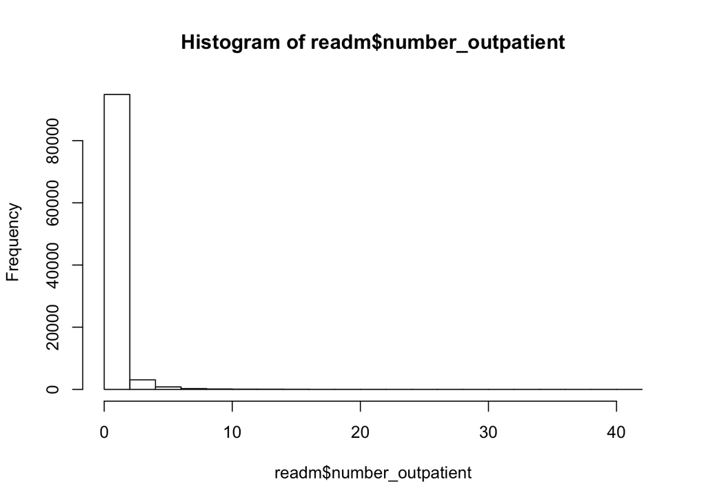

```r
hist(readm$number_outpatient) # col 13 the outlier change to bianry factor
```

```r
table(as.factor(readm$number_outpatient))
```

```
##
##     0     1     2     3     4     5     6     7     8     9    10    11
## 82994  8349  3509  1997  1077   514   294   154    96    82    57    41
##    12    13    14    15    16    17    18    19    20    21    22    23
##    29    30    28    20    13     8     5     3     6     6     5     2
##    24    25    26    27    28    29    33    34    35    36    37    38
##     3     1     2     3     1     2     2     1     2     2     1     1
##    39    40    42
##     1     1     1
```

```r
readm[readm$number_outpatient != 0,]$number_outpatient = 1
readm$number_outpatient = as.factor(readm$number_outpatient)
table(readm$number_outpatient)
```

```
##
##     0     1
## 82994 16349
```

```r
colnames(readm)[13] = 'stay_outpatient'
```

```r
#hist(readm$number_emergency) #col 14 change to binary factor
table(as.factor(readm$number_emergency))
```

```
##
##     0     1     2     3     4     5     6     7     8     9    10    11
## 88249  7474  1984   706   369   190    93    72    50    33    34    23
##    12    13    14    15    16    18    19    20    21    22    24    25
##    10    12     3     3     5     5     4     4     2     6     1     2
##    28    29    37    42    46    54    63    64    76
##     1     1     1     1     1     1     1     1     1
```

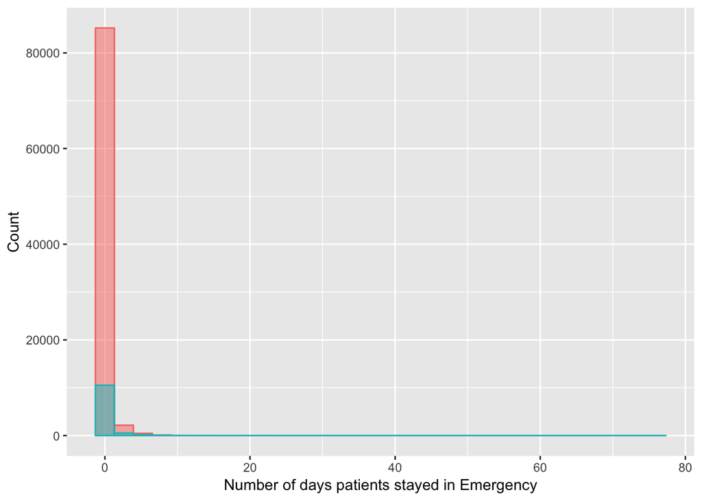

```r
ggplot(readm, aes(x=number_emergency, fill=readmitted_30, color=readmitted_30 )) +
  geom_histogram(position="identity", alpha=0.5) +
  theme(legend.position="none") +
  labs(x= 'Number of days patients stayed in Emergency', y = 'Count')
```

```r
readm[readm$number_emergency != 0,]$number_emergency = 1
readm$number_emergency = as.factor(readm$number_emergency)
table(readm$number_emergency)
```

```
##
##     0     1
## 88249 11094
```

```r
colnames(readm)[14] = 'stay_emergency'
```

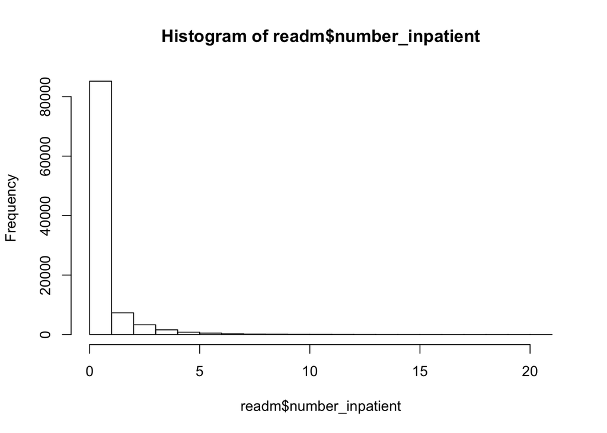

```r
hist(readm$number_inpatient) #col 15 delete the outlier change to factor
```

```r
table(as.factor(readm$number_inpatient))
```

```
##
##     0     1     2     3     4     5     6     7     8     9    10    11
## 66245 18984  7300  3271  1574   791   474   262   145   109    59    49
##    12    13    14    15    16    17    18    19    21
##    32    18    10     9     6     1     1     2     1
```

```r
readm[readm$number_inpatient >=3,]$number_inpatient = 3
readm$number_inpatient = as.factor(readm$number_inpatient)
table(readm$number_inpatient)
```

```
##
##     0     1     2     3
## 66245 18984  7300  6814
```

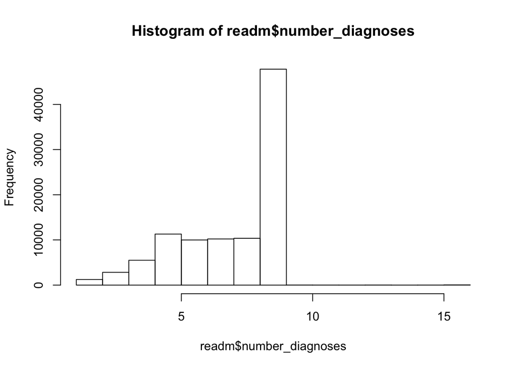

```r
hist(readm$number_diagnoses) # col 16 delete outlier >10 and change to factor of 9 levels
```

```r
table(as.factor(readm$number_diagnoses))
```

```
##
##     1     2     3     4     5     6     7     8     9    10    11    12
##   219  1021  2824  5499 11301  9986 10215 10359 47810    16    11     8
##    13    14    15    16
##    16     6    10    42
```

```r
readm[readm$number_diagnoses >=9,]$number_diagnoses = 9
readm$number_diagnoses = as.factor(readm$number_diagnoses)
table(readm$number_diagnoses)
```

```
##
##     1     2     3     4     5     6     7     8     9
##   219  1021  2824  5499 11301  9986 10215 10359 47919
```

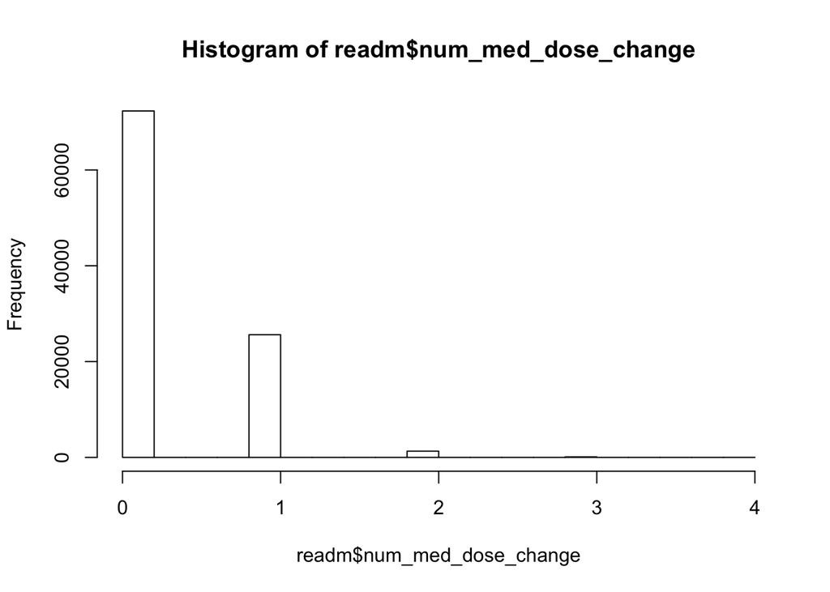

```r
hist(readm$num_med_dose_change) #col 24 change to factor of three levels
```

```r
table(as.factor(readm$num_med_dose_change))
```

```
##
##     0     1     2     3     4
## 72323 25609  1299   107     5
```

```r
readm[readm$num_med_dose_change>=2,]$num_med_dose_change = 2
readm$num_med_dose_change = as.factor(readm$num_med_dose_change)
table(readm$num_med_dose_change)
```

```
##
##     0     1     2
## 72323 25609  1411
```

### 3.3 Interation plot

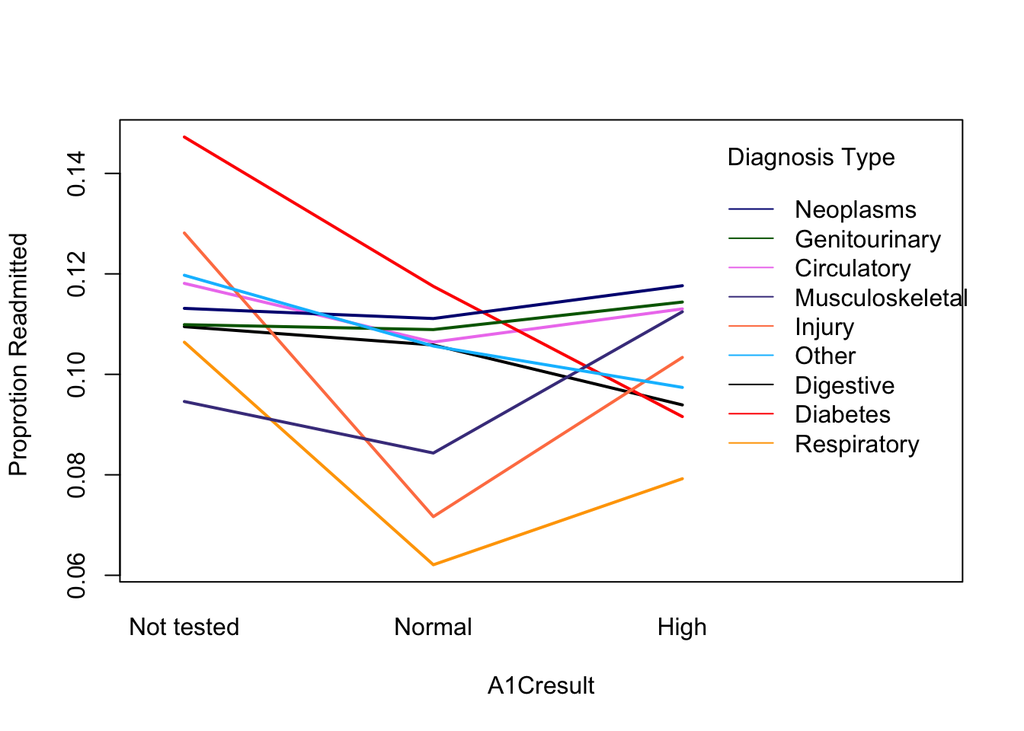

```r
int_plot =  readm %>%
  dplyr::select(diag_1, A1Cresult, readmitted_30)

int_plot$diag.cat <- factor(int_plot$diag_1, labels=  c("Circulatory", "Respiratory", "Digestive", "Diabetes", "Injury", "Musculoskeletal","Genitourinary", "Neoplasms","Other"))
int_plot$A1CResult.cat <- factor(int_plot$A1Cresult, labels=  c("Not tested", "Normal", "High"))

interaction.plot( int_plot$A1CResult.cat,int_plot$diag.cat, as.numeric(int_plot$readmitted_30)-1, fun = mean,
                  col = c("violet","orange","black","red","coral","darkslateblue","darkgreen",
                          "navyblue","deepskyblue"
                          ),lty = 1, lwd = 2,
                 trace.label ="Diagnosis Type" , xlab = "A1Cresult",ylab = "Proprotion Readmitted ")
```

```r
#str(readm)
#summary(readm$readmitted_30)
```

### 3.4. Train test split and Over sampling

```r
set.seed(123)
train.indexes = sample(nrow(readm), size=0.7*nrow(readm))

pre.Train = readm[train.indexes,]
pre.Holdout = readm[-train.indexes,]
```

```r
# library(bimba)
library(ROSE)
# library(DMwR)
```

```r
table(pre.Train$readmitted_30)
```

```
##
##     0     1
## 61631  7909
```

```r
pre.Train.SMOTE <- ovun.sample(readmitted_30 ~ ., data = pre.Train, method = "over",
N = 61631*2)$data

table(pre.Train.SMOTE$readmitted_30)
```

```
##
##     0     1
## 61631 61631
```

### 3.5 Prediction Random Forest

```r
library(randomForest)
library(AUC)
library(caret)
set.seed(202)
Train.rf.fit <- randomForest(readmitted_30 ~ ., data=pre.Train)
```

```r
#plot(Train.rf.fit)
#legend('topright', colnames(Train.rf.fit$err.rate), col=1:3, fill=1:3) plot using 0.5 as threshold
```

```r
Train.rf.fit.prediction = predict(Train.rf.fit,type="prob")[,2]
head(Train.rf.fit.prediction )
```

```
##         1         2         3         4         5         6
## 0.1977401 0.0950000 0.1139241 0.1371429 0.1481481 0.1075269
```

```r
Train.rf.fit.prediction[Train.rf.fit.prediction >= 0.103] = 1
Train.rf.fit.prediction[Train.rf.fit.prediction < 0.103] = 0
```

```r
table(pre.Train$readmitted_30,Train.rf.fit.prediction) # has a mistake, should be real value first, then predicted, anything else such as confusion matrix and roc should be the other way
```

```
##    Train.rf.fit.prediction
##         0     1
##   0 30854 30777
##   1  2383  5526
```

```r
round(prop.table(table(pre.Train$readmitted_30,Train.rf.fit.prediction),1),4)
```

```
##    Train.rf.fit.prediction
##          0      1
##   0 0.5006 0.4994
##   1 0.3013 0.6987
```

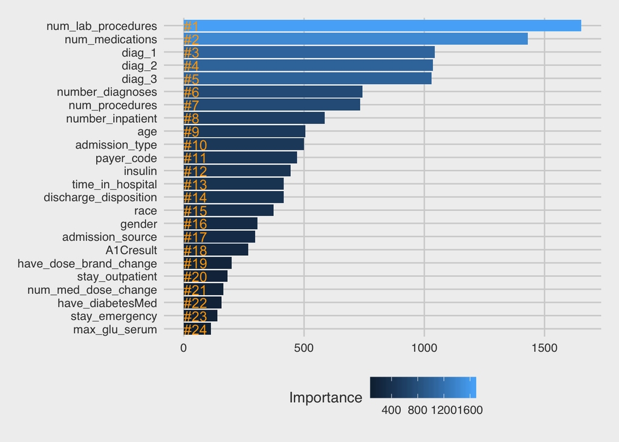

```r
# Get importance
importance =  importance(Train.rf.fit)
varImportance <- data.frame(Variables = row.names(importance),
                            Importance = round(importance[ ,'MeanDecreaseGini'],2))

# Create a rank variable based on importance
rankImportance <- varImportance %>%
  mutate(Rank = paste0('#',dense_rank(desc(Importance))))

# Use ggplot2 to visualize the relative importance of variables
ggplot(rankImportance, aes(x = reorder(Variables, Importance),
    y = Importance, fill = Importance)) +
  geom_bar(stat='identity') +
  geom_text(aes(x = Variables, y = 0.5, label = Rank),
    hjust=0, vjust=0.55, size = 4, colour = 'orange') +
  labs(x = 'Variables') +
  coord_flip() +
  theme_fivethirtyeight()
```

```r
Test.rf.fit.prediction = predict(Train.rf.fit,newdata=pre.Holdout[,-1],type="prob")[,2]
head(Test.rf.fit.prediction )
```

```
##     1     2     3     4     5     6
## 0.026 0.096 0.142 0.178 0.092 0.126
```

```r
Test.rf.fit.prediction[Test.rf.fit.prediction >= 0.103] = 1
Test.rf.fit.prediction[Test.rf.fit.prediction < 0.103] = 0
```

```r
confusionMatrix(as.factor(Test.rf.fit.prediction),pre.Holdout[[1]], positive = '1')
```

```
## Confusion Matrix and Statistics
##
##           Reference
## Prediction     0     1
##          0 13268  1016
##          1 13130  2389
##
##                Accuracy : 0.5253
##                  95% CI : (0.5197, 0.531)
##     No Information Rate : 0.8857
##     P-Value [Acc > NIR] : 1
##
##                   Kappa : 0.0801
##  Mcnemar's Test P-Value : <2e-16
##
##             Sensitivity : 0.70162
##             Specificity : 0.50261
##          Pos Pred Value : 0.15394
##          Neg Pred Value : 0.92887
##              Prevalence : 0.11425
##          Detection Rate : 0.08016
##    Detection Prevalence : 0.52072
##       Balanced Accuracy : 0.60211
##
##        'Positive' Class : 1
##
```

```r
table(pre.Holdout$readmitted_30,Test.rf.fit.prediction)
```

```
##    Test.rf.fit.prediction
##         0     1
##   0 13268 13130
##   1  1016  2389
```

```r
round(prop.table(table(pre.Holdout$readmitted_30,Test.rf.fit.prediction),1),4)
```

```
##    Test.rf.fit.prediction
##          0      1
##   0 0.5026 0.4974
##   1 0.2984 0.7016
```

```r
Test.rf.fit.prediction.num = predict(Train.rf.fit,newdata=pre.Holdout[,-1],type="prob")[,2]
auc(roc(Test.rf.fit.prediction.num, pre.Holdout$readmitted_30))
```

```
## [1] 0.649923
```

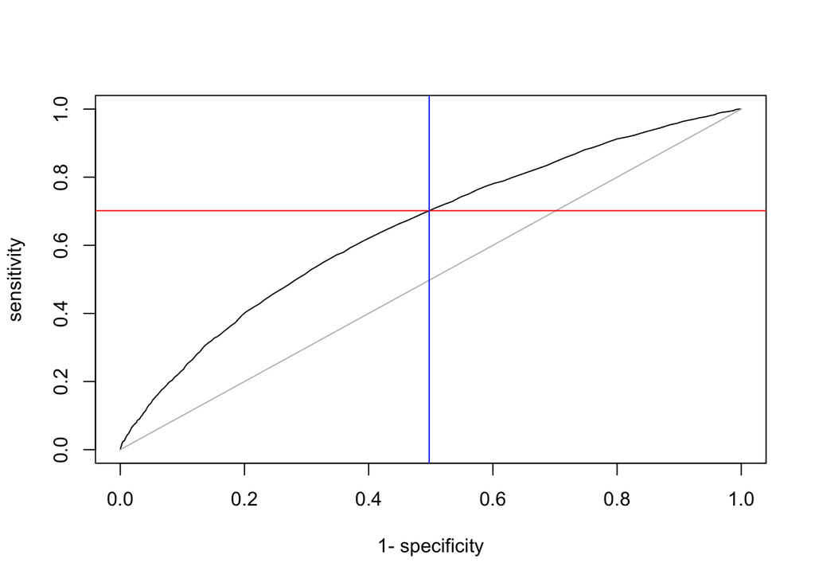

```r
plot(roc(Test.rf.fit.prediction.num, pre.Holdout$readmitted_30))
abline(h = 0.7016153, col = 'red')
abline(v = 0.4973862, col = 'blue')
```

```r
rf.roc = cbind.data.frame(fpr =roc(Test.rf.fit.prediction.num, pre.Holdout$readmitted_30)$fpr, tpr = roc(Test.rf.fit.prediction.num, pre.Holdout$readmitted_30)$tpr)
```

### 3.6 Prediction using Logistic

```r
library(MASS)
glm.full = glm(readmitted_30~. ,data=pre.Train.SMOTE, family=binomial(link=logit))
summary(glm.full)
```

```
##
## Call:
## glm(formula = readmitted_30 ~ ., family = binomial(link = logit),
##     data = pre.Train.SMOTE)
##
## Deviance Residuals:
##      Min        1Q    Median        3Q       Max
## -2.13235  -1.07271  -0.06234   1.13319   1.85486
##
## Coefficients:
##                           Estimate Std. Error z value Pr(>|z|)
## (Intercept)             -1.4259959  0.1573684  -9.062  < 2e-16 ***
## race2                   -0.0060231  0.0766810  -0.079 0.937393
## race3                   -0.0312574  0.0157191  -1.988 0.046757 *
## race4                   -0.1156495  0.0452832  -2.554 0.010652 *
## race5                   -0.0089573  0.0512330  -0.175 0.861209
## gender2                  0.0606530  0.0121303   5.000 5.73e-07 ***
## age2                     0.5769374  0.0841568   6.856 7.11e-12 ***
## age3                     0.3643362  0.0826806   4.407 1.05e-05 ***
## age4                     0.4793751  0.0832136   5.761 8.37e-09 ***
## age5                     0.4406534  0.0845676   5.211 1.88e-07 ***
## admission_type2         -0.0090976  0.0197295  -0.461 0.644715
## admission_type3         -0.0556259  0.0240450  -2.313 0.020700 *
## admission_type4         -0.1178836  0.0298475  -3.950 7.83e-05 ***
## discharge_disposition2   0.5937412  0.0160874  36.907  < 2e-16 ***
## discharge_disposition3   0.1747386  0.0187723   9.308  < 2e-16 ***
## discharge_disposition4   0.2928778  0.0271153  10.801  < 2e-16 ***
## admission_source2       -0.0385741  0.0194330  -1.985 0.047147 *
## admission_source3       -0.1575341  0.0367174  -4.290 1.78e-05 ***
## payer_code2              0.1108948  0.0171230   6.476 9.40e-11 ***
## payer_code3              0.0445057  0.0307485   1.447 0.147783
## payer_code4              0.1573454  0.0186691   8.428  < 2e-16 ***
## time_in_hospital2        0.0416978  0.0154392   2.701 0.006918 **
## time_in_hospital3        0.0370894  0.0187470   1.978 0.047881 *
## num_lab_procedures       0.0012169  0.0003615   3.366 0.000762 ***
## num_procedures1          0.0442915  0.0165974   2.669 0.007617 **
## num_procedures2         -0.0208665  0.0201350  -1.036 0.300048
## num_procedures3         -0.0105737  0.0227901  -0.464 0.642675
## num_procedures4         -0.0660243  0.0222577  -2.966 0.003013 **
## num_medications          0.0746556  0.0152274   4.903 9.45e-07 ***
```

[output cut: 43 more lines]

```
## num_med_dose_change1     0.0781026  0.0328606   2.377 0.017464 *
## num_med_dose_change2     0.1105576  0.0570408   1.938 0.052597 .
## insulin1                -0.1688911  0.0347479  -4.860 1.17e-06 ***
## insulin2                -0.1270735  0.0350428  -3.626 0.000288 ***
## insulin4                -0.0553496  0.0238563  -2.320 0.020334 *
## ---
## Signif. codes:  0 '***' 0.001 '**' 0.01 '*' 0.05 '.' 0.1 ' ' 1
##
## (Dispersion parameter for binomial family taken to be 1)
##
##     Null deviance: 170877  on 123261  degrees of freedom
## Residual deviance: 160915  on 123185  degrees of freedom
## AIC: 161069
##
## Number of Fisher Scoring iterations: 4
```

```r
#stepAIC(glm.full, direction="backward", trace = FALSE) # very long time
```

```r
glm.predict = glm(formula = readmitted_30 ~ race + gender + age + admission_type +
    discharge_disposition + admission_source + payer_code + time_in_hospital +
    num_lab_procedures + num_procedures + num_medications + stay_outpatient +
    stay_emergency + number_inpatient + number_diagnoses + diag_1 +
    diag_2 + diag_3 + max_glu_serum + A1Cresult + have_diabetesMed +
    have_dose_brand_change + num_med_dose_change + insulin, family = binomial(link = logit),
    data = pre.Train.SMOTE)
summary(glm.predict)
```

```
##
## Call:
## glm(formula = readmitted_30 ~ race + gender + age + admission_type +
##     discharge_disposition + admission_source + payer_code + time_in_hospital +
##     num_lab_procedures + num_procedures + num_medications + stay_outpatient +
##     stay_emergency + number_inpatient + number_diagnoses + diag_1 +
##     diag_2 + diag_3 + max_glu_serum + A1Cresult + have_diabetesMed +
##     have_dose_brand_change + num_med_dose_change + insulin, family = binomial(link = logit),
##     data = pre.Train.SMOTE)
##
## Deviance Residuals:
##      Min        1Q    Median        3Q       Max
## -2.13235  -1.07271  -0.06234   1.13319   1.85486
##
## Coefficients:
##                           Estimate Std. Error z value Pr(>|z|)
## (Intercept)             -1.4259959  0.1573684  -9.062  < 2e-16 ***
## race2                   -0.0060231  0.0766810  -0.079 0.937393
## race3                   -0.0312574  0.0157191  -1.988 0.046757 *
## race4                   -0.1156495  0.0452832  -2.554 0.010652 *
## race5                   -0.0089573  0.0512330  -0.175 0.861209
## gender2                  0.0606530  0.0121303   5.000 5.73e-07 ***
## age2                     0.5769374  0.0841568   6.856 7.11e-12 ***
## age3                     0.3643362  0.0826806   4.407 1.05e-05 ***
## age4                     0.4793751  0.0832136   5.761 8.37e-09 ***
## age5                     0.4406534  0.0845676   5.211 1.88e-07 ***
## admission_type2         -0.0090976  0.0197295  -0.461 0.644715
## admission_type3         -0.0556259  0.0240450  -2.313 0.020700 *
## admission_type4         -0.1178836  0.0298475  -3.950 7.83e-05 ***
## discharge_disposition2   0.5937412  0.0160874  36.907  < 2e-16 ***
## discharge_disposition3   0.1747386  0.0187723   9.308  < 2e-16 ***
## discharge_disposition4   0.2928778  0.0271153  10.801  < 2e-16 ***
## admission_source2       -0.0385741  0.0194330  -1.985 0.047147 *
## admission_source3       -0.1575341  0.0367174  -4.290 1.78e-05 ***
## payer_code2              0.1108948  0.0171230   6.476 9.40e-11 ***
## payer_code3              0.0445057  0.0307485   1.447 0.147783
## payer_code4              0.1573454  0.0186691   8.428  < 2e-16 ***
## time_in_hospital2        0.0416978  0.0154392   2.701 0.006918 **
## time_in_hospital3        0.0370894  0.0187470   1.978 0.047881 *
## num_lab_procedures       0.0012169  0.0003615   3.366 0.000762 ***
```

[output cut: 48 more lines]

```
## num_med_dose_change1     0.0781026  0.0328606   2.377 0.017464 *
## num_med_dose_change2     0.1105576  0.0570408   1.938 0.052597 .
## insulin1                -0.1688911  0.0347479  -4.860 1.17e-06 ***
## insulin2                -0.1270735  0.0350428  -3.626 0.000288 ***
## insulin4                -0.0553496  0.0238563  -2.320 0.020334 *
## ---
## Signif. codes:  0 '***' 0.001 '**' 0.01 '*' 0.05 '.' 0.1 ' ' 1
##
## (Dispersion parameter for binomial family taken to be 1)
##
##     Null deviance: 170877  on 123261  degrees of freedom
## Residual deviance: 160915  on 123185  degrees of freedom
## AIC: 161069
##
## Number of Fisher Scoring iterations: 4
```

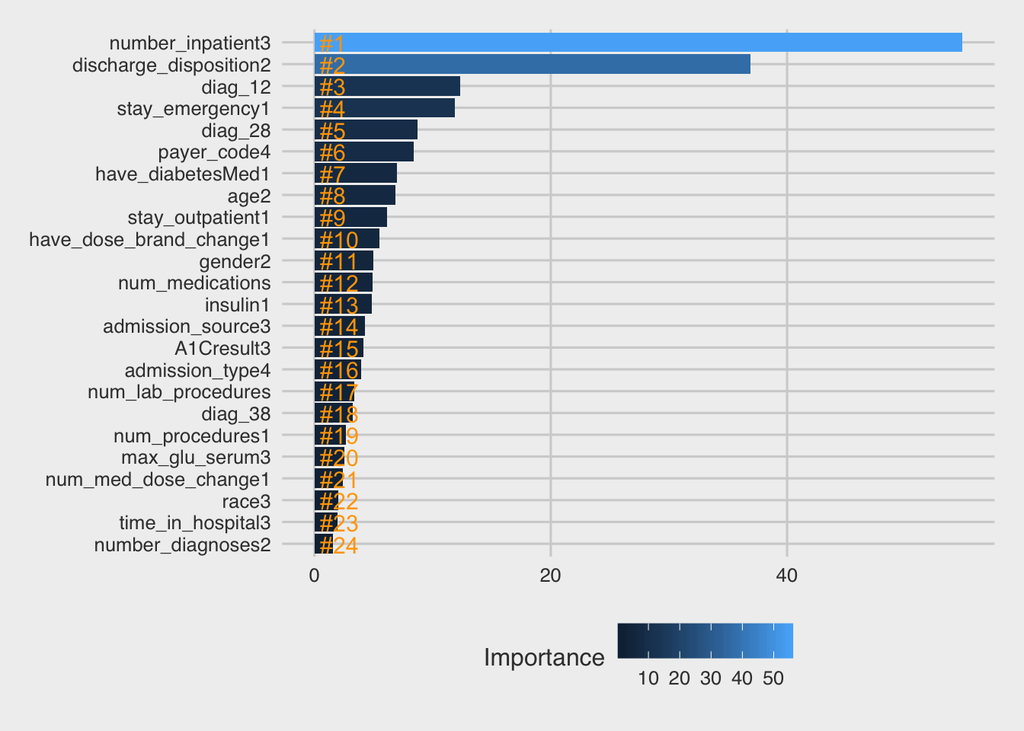

```r
# Get importance
importance.all = varImp(glm.predict, scale = FALSE)
name.all = rownames(importance.all)

importance = importance.all[c(2,5,6,12,13,17,20,22:24,28:30,33,34,42,56,64,67,69:72,74),]

varImportance <- data.frame(Variables =  name.all[c(2,5,6,12,13,17,20,22:24,28:30,33,34,42,56,64,67,69:72,74)],
                            Importance = round(importance,2))

# Create a rank variable based on importance
rankImportance <- varImportance %>%
  mutate(Rank = paste0('#',dense_rank(desc(Importance))))

# Use ggplot2 to visualize the relative importance of variables
ggplot(rankImportance, aes(x = reorder(Variables, Importance),
    y = Importance, fill = Importance)) +
  geom_bar(stat='identity') +
  geom_text(aes(x = Variables, y = 0.5, label = Rank),
    hjust=0, vjust=0.55, size = 4, colour = 'orange') +
  labs(x = 'Variables') +
  coord_flip() +
  theme_fivethirtyeight()
```

```r
lr.predicted.train = glm.predict$fitted.values
lr.predicted.train[lr.predicted.train >= .44] = 1
lr.predicted.train[lr.predicted.train < .44] = 0

table(pre.Train.SMOTE$readmitted_30,lr.predicted.train) #this is correct
```

```
##    lr.predicted.train
##         0     1
##   0 31284 30347
##   1 17287 44344
```

```r
round(prop.table(table(pre.Train.SMOTE$readmitted_30 ,lr.predicted.train),1),5)
```

```
##    lr.predicted.train
##           0       1
##   0 0.50760 0.49240
##   1 0.28049 0.71951
```

```r
lr.predicted.holdout = predict(glm.predict, newdata = pre.Holdout, type="response")

lr.predicted.holdout[lr.predicted.holdout >= .44] = 1
lr.predicted.holdout[lr.predicted.holdout < .44] = 0
```

```r
confusionMatrix(as.factor(lr.predicted.holdout), ref= pre.Holdout$readmitted_30, positive = '1')
```

```
## Confusion Matrix and Statistics
##
##           Reference
## Prediction     0     1
##          0 13452   942
##          1 12946  2463
##
##                Accuracy : 0.534
##                  95% CI : (0.5283, 0.5397)
##     No Information Rate : 0.8857
##     P-Value [Acc > NIR] : 1
##
##                   Kappa : 0.0919
##  Mcnemar's Test P-Value : <2e-16
##
##             Sensitivity : 0.72335
##             Specificity : 0.50958
##          Pos Pred Value : 0.15984
##          Neg Pred Value : 0.93456
##              Prevalence : 0.11425
##          Detection Rate : 0.08264
##    Detection Prevalence : 0.51703
##       Balanced Accuracy : 0.61647
##
##        'Positive' Class : 1
##
```

```r
table(pre.Holdout$readmitted_30,lr.predicted.holdout)
```

```
##    lr.predicted.holdout
##         0     1
##   0 13452 12946
##   1   942  2463
```

```r
round(prop.table(table(pre.Holdout$readmitted_30,lr.predicted.holdout),1),5)
```

```
##    lr.predicted.holdout
##           0       1
##   0 0.50958 0.49042
##   1 0.27665 0.72335
```

```r
#prop.table(table(pre.Holdout$readmitted_30,predicted.holdout),1)
```

```r
predicted.holdout.num = predict(glm.predict, newdata = pre.Holdout, type="response")
head(predicted.holdout.num)
```

```
##         1         2         3         4         5         6
## 0.2319653 0.3284663 0.4926481 0.4346224 0.4736241 0.5074587
```

```r
lr.holdout.num = cbind.data.frame(lr.holdout.pre.1 = predicted.holdout.num, lr.holdout.pre.0 = 1- predicted.holdout.num)

auc(roc(predicted.holdout.num, pre.Holdout$readmitted_30))
```

```
## [1] 0.6592409
```

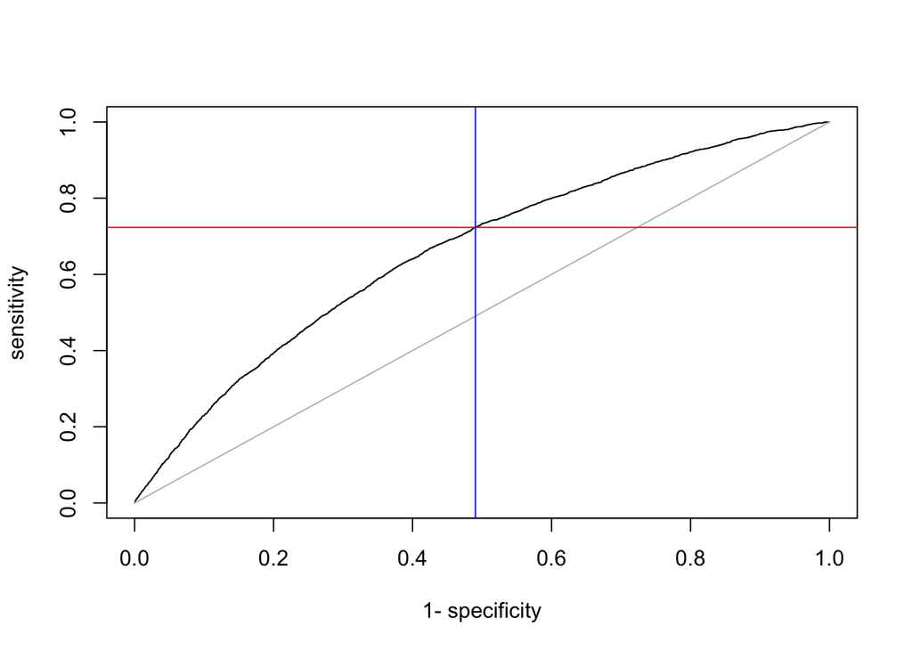

```r
plot(roc(predicted.holdout.num, pre.Holdout$readmitted_30))
abline(h = 0.7233480, col = 'red')
abline(v = 0.4904159, col = 'blue')
```

```r
lr.roc = cbind.data.frame(fpr =roc(predicted.holdout.num, pre.Holdout$readmitted_30)$fpr, tpr = roc(predicted.holdout.num, pre.Holdout$readmitted_30)$tpr)
```

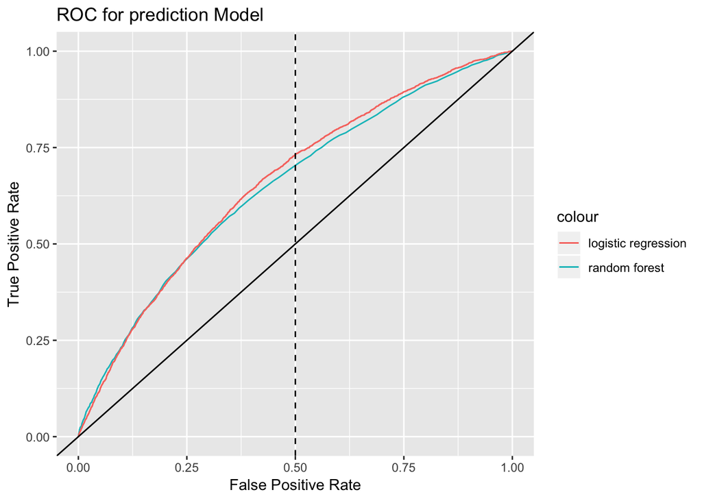

```r
ggplot() +
  geom_line(data = rf.roc, aes(x = fpr, y = tpr,color = "random forest")) +
  geom_line(data = lr.roc, aes(x = fpr, y = tpr, color = 'logistic regression')) +
  geom_abline(intercept =0, slope = 1, color=" black") +
  geom_vline(xintercept = 0.5, linetype="dashed", color = "black") +
  labs(x= 'False Positive Rate', y = 'True Positive Rate', title="ROC for prediction Model")
```